# Healthcare Analysis

```
 * NIDDK (National Institute of Diabetes and Digestive and Kidney Diseases) research creates knowledge about and treatments for the most chronic, costly, and consequential diseases.
 * The dataset used in this project is originally from NIDDK. The objective is to predict whether or not a patient has diabetes, based on certain diagnostic measurements included in the dataset.
 * Build a model to accurately predict whether the patients in the dataset have diabetes or not.
```

```python
#importing required packages
import pandas as pd
import numpy as np
import matplotlib.pyplot as plt
import seaborn as sns
%matplotlib inline
```

```python
#importing dataset
healthcare_df = pd.read_csv('health care diabetes.csv')
```

```python
healthcare_df.head()
```

|  | Pregnancies | Glucose | BloodPressure | SkinThickness | Insulin | BMI | DiabetesPedigreeFunction | Age | Outcome |
| --- | --- | --- | --- | --- | --- | --- | --- | --- | --- |
| 0 | 6 | 148 | 72 | 35 | 0 | 33.6 | 0.627 | 50 | 1 |
| 1 | 1 | 85 | 66 | 29 | 0 | 26.6 | 0.351 | 31 | 0 |
| 2 | 8 | 183 | 64 | 0 | 0 | 23.3 | 0.672 | 32 | 1 |
| 3 | 1 | 89 | 66 | 23 | 94 | 28.1 | 0.167 | 21 | 0 |
| 4 | 0 | 137 | 40 | 35 | 168 | 43.1 | 2.288 | 33 | 1 |

**Descriptive Analysis:**

```python
healthcare_df.columns
```

```
Index(['Pregnancies', 'Glucose', 'BloodPressure', 'SkinThickness', 'Insulin',
       'BMI', 'DiabetesPedigreeFunction', 'Age', 'Outcome'],
      dtype='object')
```

```python
healthcare_df.shape
```

```
(768, 9)
```

```python
healthcare_df.info()
```

```
<class 'pandas.core.frame.DataFrame'>
RangeIndex: 768 entries, 0 to 767
Data columns (total 9 columns):
 #   Column                    Non-Null Count  Dtype
---  ------                    --------------  -----
 0   Pregnancies               768 non-null    int64
 1   Glucose                   768 non-null    int64
 2   BloodPressure             768 non-null    int64
 3   SkinThickness             768 non-null    int64
 4   Insulin                   768 non-null    int64
 5   BMI                       768 non-null    float64
 6   DiabetesPedigreeFunction  768 non-null    float64
 7   Age                       768 non-null    int64
 8   Outcome                   768 non-null    int64
dtypes: float64(2), int64(7)
memory usage: 54.1 KB
```

```python
#checking for null values
healthcare_df.isnull().any()
```

```
Pregnancies                 False
Glucose                     False
BloodPressure               False
SkinThickness               False
Insulin                     False
BMI                         False
DiabetesPedigreeFunction    False
Age                         False
Outcome                     False
dtype: bool
```

```python
#Description of Dataset
healthcare_df.describe().transpose()
```

|  | count | mean | std | min | 25% | 50% | 75% | max |
| --- | --- | --- | --- | --- | --- | --- | --- | --- |
| Pregnancies | 768.0 | 3.845052 | 3.369578 | 0.000 | 1.00000 | 3.0000 | 6.00000 | 17.00 |
| Glucose | 768.0 | 120.894531 | 31.972618 | 0.000 | 99.00000 | 117.0000 | 140.25000 | 199.00 |
| BloodPressure | 768.0 | 69.105469 | 19.355807 | 0.000 | 62.00000 | 72.0000 | 80.00000 | 122.00 |
| SkinThickness | 768.0 | 20.536458 | 15.952218 | 0.000 | 0.00000 | 23.0000 | 32.00000 | 99.00 |
| Insulin | 768.0 | 79.799479 | 115.244002 | 0.000 | 0.00000 | 30.5000 | 127.25000 | 846.00 |
| BMI | 768.0 | 31.992578 | 7.884160 | 0.000 | 27.30000 | 32.0000 | 36.60000 | 67.10 |
| DiabetesPedigreeFunction | 768.0 | 0.471876 | 0.331329 | 0.078 | 0.24375 | 0.3725 | 0.62625 | 2.42 |
| Age | 768.0 | 33.240885 | 11.760232 | 21.000 | 24.00000 | 29.0000 | 41.00000 | 81.00 |
| Outcome | 768.0 | 0.348958 | 0.476951 | 0.000 | 0.00000 | 0.0000 | 1.00000 | 1.00 |

```python
#variation of each variable
healthcare_df.apply(np.std)
```

```
Pregnancies                   3.367384
Glucose                      31.951796
BloodPressure                19.343202
SkinThickness                15.941829
Insulin                     115.168949
BMI                           7.879026
DiabetesPedigreeFunction      0.331113
Age                          11.752573
Outcome                       0.476641
dtype: float64
```

**Treating Missing Values(Zero):**

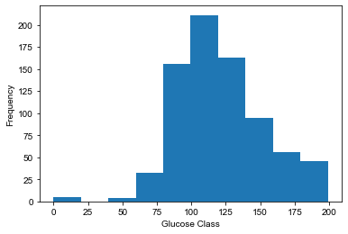

```python
#Treating the zero values for the Glucose Variable
plt.figure(figsize=(6,4))
plt.xlabel('Glucose Class')
healthcare_df['Glucose'].plot.hist()
sns.set_style(style='darkgrid')
```

```python
healthcare_df['Glucose'].mean()
```

```
120.89453125
```

From the above histogram, it is clear that few values of Glucose variable have zero. Replacing the zero values with mean of the variable since less number of zero values are present.

```python
#replacing the zero with the mean of the variable
healthcare_df['Glucose']=healthcare_df['Glucose'].replace(0,healthcare_df['Glucose'].mean())
```

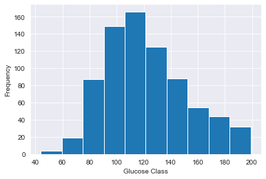

```python
#After Replacement Treatment
plt.figure(figsize=(6,4))
plt.xlabel('Glucose Class')
healthcare_df['Glucose'].plot.hist()
sns.set_style(style='darkgrid')
```

```python
healthcare_df['Glucose'].mean()
```

```
121.68160502115886
```

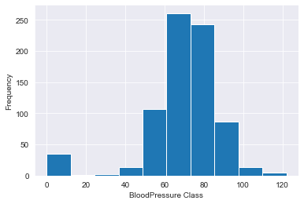

```python
#Treating the zero values for the BloodPressure Variable
plt.figure(figsize=(6,4))
plt.xlabel('BloodPressure Class')
healthcare_df['BloodPressure'].plot.hist()
sns.set_style(style='darkgrid')
```

From the above histogram, it is clear that few values of Bloodpressure variable have zero. Replacing the zero values with mean of the variable since less number of zero values are present.

```python
healthcare_df['BloodPressure'].mean()
```

```
69.10546875
```

```python
#replacing the zero with the mean of the variable
healthcare_df['BloodPressure']=healthcare_df['BloodPressure'].replace(0,healthcare_df['BloodPressure'].mean())
```

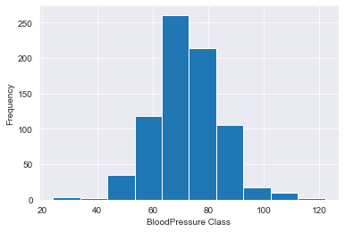

```python
#After Replacement Treatment
plt.figure(figsize=(6,4))
plt.xlabel('BloodPressure Class')
healthcare_df['BloodPressure'].plot.hist()
sns.set_style(style='darkgrid')
```

```python
healthcare_df['BloodPressure'].mean()
```

```
72.25480651855469
```

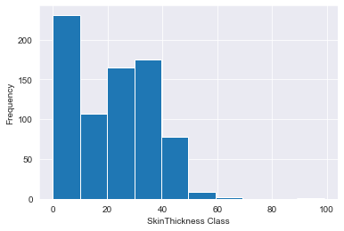

```python
#Treating the zero values for the SkinThickness Variable
plt.figure(figsize=(6,4))
plt.xlabel('SkinThickness Class')
healthcare_df['SkinThickness'].plot.hist()
sns.set_style(style='darkgrid')
```

```python
healthcare_df['SkinThickness'].value_counts().head()
```

```
0     227
32     31
30     27
27     23
23     22
Name: SkinThickness, dtype: int64
```

```python
print(healthcare_df['SkinThickness'].mean())
print(healthcare_df['SkinThickness'].median())
```

```
20.536458333333332
23.0
```

Just gave a try to prove how biased the dataset is when we replace the zero with mean or median.

```python
skinthickness_treat=healthcare_df['SkinThickness'].replace(0,healthcare_df['SkinThickness'].median())
```

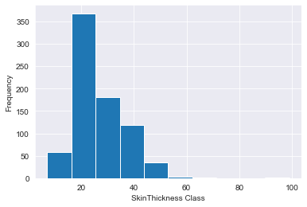

```python
plt.figure(figsize=(6,4))
plt.xlabel('SkinThickness Class')
skinthickness_treat.plot.hist()
sns.set_style(style='darkgrid')
```

```python
#Checking for value counts after replacement
skinthickness_treat.value_counts().head()
```

```
23    249
32     31
30     27
27     23
33     20
Name: SkinThickness, dtype: int64
```

It is cleared that the skinthickness variabe is biased. So we try with interpolate missing value treatment.

```python
healthcare_df['SkinThickness'].replace(0, np.nan, inplace=True)
```

```python
healthcare_df['SkinThickness'].isna().sum()
```

```
227
```

```python
#using interpolate function
healthcare_df['SkinThickness'].interpolate(method ='linear', limit_direction ='forward', inplace=True)
```

```python
healthcare_df['SkinThickness'].isna().sum()
```

```
0
```

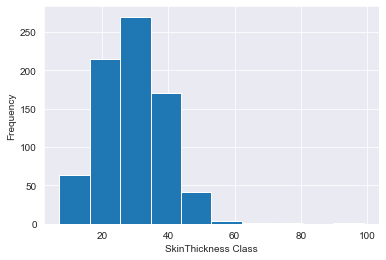

```python
#after using interpolate function
plt.figure(figsize=(6,4))
plt.xlabel('SkinThickness Class')
healthcare_df['SkinThickness'].plot.hist()
sns.set_style(style='darkgrid')
```

```python
healthcare_df['SkinThickness'].value_counts().head(10)
```

```
32.0    33
27.0    32
30.0    30
33.0    24
23.0    23
18.0    22
31.0    22
28.0    22
19.0    22
39.0    21
Name: SkinThickness, dtype: int64
```

Now from the above we can observe that the Values are spreaded almost evenly.

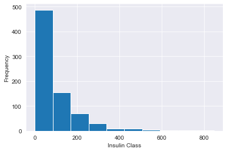

```python
#Treating the zero values for the Insulin Variable
plt.figure(figsize=(6,4))
plt.xlabel('Insulin Class')
healthcare_df['Insulin'].plot.hist()
sns.set_style(style='darkgrid')
```

```python
healthcare_df['Insulin'].value_counts().head()
```

```
0      374
105     11
140      9
130      9
120      8
Name: Insulin, dtype: int64
```

Since Insulin variable also have many zero values like Skinthickness Variable. We use the same interpolate method to treat zero values.

```python
print(healthcare_df['Insulin'].mean())
print(healthcare_df['Insulin'].median())
```

```
79.79947916666667
30.5
```

```python
insulin_treat=healthcare_df['Insulin'].replace(0,healthcare_df['Insulin'].mean())
```

```python
insulin_treat.mean()
```

```
118.66016303168442
```

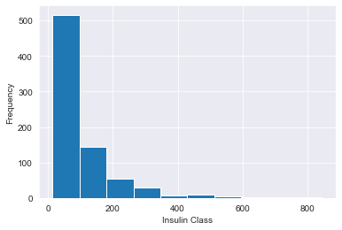

```python
plt.figure(figsize=(6,4))
plt.xlabel('Insulin Class')
insulin_treat.plot.hist()
sns.set_style(style='darkgrid')
```

```python
insulin_treat.value_counts().head()
```

```
79.799479     374
105.000000     11
130.000000      9
140.000000      9
120.000000      8
Name: Insulin, dtype: int64
```

```python
healthcare_df['Insulin'].replace(0, np.nan, inplace=True)
```

```python
healthcare_df['Insulin'].isna().sum()
```

```
374
```

```python
healthcare_df['Insulin'].interpolate(method ='linear', limit_direction ='forward', inplace=True)
```

```python
healthcare_df['Insulin'].isna().sum()
```

```
3
```

```python
healthcare_df['Insulin'].interpolate(method ='linear', limit_direction ='backward', inplace=True)
```

```python
healthcare_df['Insulin'].isna().sum()
```

```
0
```

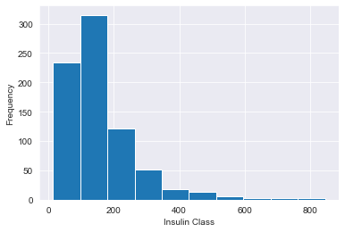

```python
plt.figure(figsize=(6,4))
plt.xlabel('Insulin Class')
healthcare_df['Insulin'].plot.hist()
sns.set_style(style='darkgrid')
```

```python
healthcare_df['Insulin'].value_counts().head(10)
```

```
130.0    13
105.0    12
140.0    11
94.0     10
120.0     9
135.0     9
100.0     9
56.0      8
110.0     7
180.0     7
Name: Insulin, dtype: int64
```

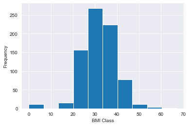

```python
#Treating the zero values for the BMI Variable
plt.figure(figsize=(6,4))
plt.xlabel('BMI Class')
healthcare_df['BMI'].plot.hist()
sns.set_style(style='darkgrid')
```

```python
print(healthcare_df['BMI'].mean())
print(healthcare_df['BMI'].median())
```

```
31.992578124999977
32.0
```

```python
healthcare_df['BMI']=healthcare_df['BMI'].replace(0,healthcare_df['BMI'].mean())
```

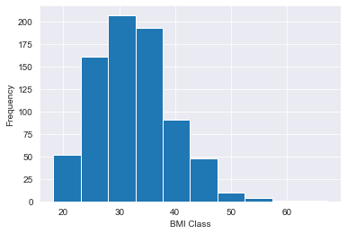

```python
plt.figure(figsize=(6,4))
plt.xlabel('BMI Class')
healthcare_df['BMI'].plot.hist()
sns.set_style(style='darkgrid')
```

```python
healthcare_df['BMI'].mean()
```

```
32.45080515543617
```

```python
healthcare_df.isnull().any()
```

```
Pregnancies                 False
Glucose                     False
BloodPressure               False
SkinThickness               False
Insulin                     False
BMI                         False
DiabetesPedigreeFunction    False
Age                         False
Outcome                     False
dtype: bool
```

```python
healthcare_df.describe().transpose()
```

|  | count | mean | std | min | 25% | 50% | 75% | max |
| --- | --- | --- | --- | --- | --- | --- | --- | --- |
| Pregnancies | 768.0 | 3.845052 | 3.369578 | 0.000 | 1.00000 | 3.0000 | 6.00000 | 17.00 |
| Glucose | 768.0 | 121.681605 | 30.436016 | 44.000 | 99.75000 | 117.0000 | 140.25000 | 199.00 |
| BloodPressure | 768.0 | 72.254807 | 12.115932 | 24.000 | 64.00000 | 72.0000 | 80.00000 | 122.00 |
| SkinThickness | 768.0 | 29.080078 | 9.887474 | 7.000 | 22.00000 | 29.0000 | 36.00000 | 99.00 |
| Insulin | 768.0 | 158.791016 | 111.453090 | 14.000 | 88.00000 | 130.0000 | 190.12500 | 846.00 |
| BMI | 768.0 | 32.450805 | 6.875374 | 18.200 | 27.50000 | 32.0000 | 36.60000 | 67.10 |
| DiabetesPedigreeFunction | 768.0 | 0.471876 | 0.331329 | 0.078 | 0.24375 | 0.3725 | 0.62625 | 2.42 |
| Age | 768.0 | 33.240885 | 11.760232 | 21.000 | 24.00000 | 29.0000 | 41.00000 | 81.00 |
| Outcome | 768.0 | 0.348958 | 0.476951 | 0.000 | 0.00000 | 0.0000 | 1.00000 | 1.00 |

Visually explored using each variable using histogram and the zero values are treated.

**Exploring Data:**

```python
print("Value Counts of Insulin: ",healthcare_df['Insulin'].value_counts().head(),end="\n\n")
print("Value Counts of BMI: ",healthcare_df['BMI'].value_counts().head(),end="\n\n")
print("Value Counts of Age: ",healthcare_df['Age'].value_counts().head(),end="\n\n")
print("Value Counts of DiabetesPedigreeFunction: ",healthcare_df['DiabetesPedigreeFunction'].value_counts().head(),end="\n\n")
print("Value Counts of SkinThickness: ",healthcare_df['SkinThickness'].value_counts().head(),end="\n\n")
print("Value Counts of Glucose: ",healthcare_df['Glucose'].value_counts().head(),end="\n\n")
print("Value Counts of BloodPressure: ",healthcare_df['BloodPressure'].value_counts().head(),end="\n\n")
print("Value Counts of Pregnancies: ",healthcare_df['Pregnancies'].value_counts().head())
```

```
Value Counts of Insulin:  130.0    13
105.0    12
140.0    11
94.0     10
120.0     9
Name: Insulin, dtype: int64

Value Counts of BMI:  32.000000    13
31.600000    12
31.200000    12
31.992578    11
33.300000    10
Name: BMI, dtype: int64

Value Counts of Age:  22    72
21    63
25    48
24    46
23    38
Name: Age, dtype: int64

Value Counts of DiabetesPedigreeFunction:  0.254    6
0.258    6
0.259    5
0.238    5
0.207    5
Name: DiabetesPedigreeFunction, dtype: int64

Value Counts of SkinThickness:  32.0    33
27.0    32
30.0    30
33.0    24
23.0    23
Name: SkinThickness, dtype: int64

Value Counts of Glucose:  100.0    17
99.0     17
125.0    14
106.0    14
111.0    14
Name: Glucose, dtype: int64

Value Counts of BloodPressure:  70.0    57
74.0    52
68.0    45
78.0    45
72.0    44
Name: BloodPressure, dtype: int64

Value Counts of Pregnancies:  1    135
0    111
2    103
3     75
4     68
Name: Pregnancies, dtype: int64
```

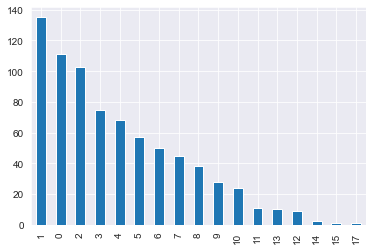

```python
#frequency count of pregnancies variable
healthcare_df['Pregnancies'].value_counts().plot(kind='bar')
```

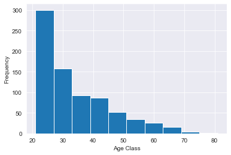

```python
#frequency count of Age variable
plt.figure(figsize=(6,4))
plt.xlabel('Age Class')
healthcare_df['Age'].plot.hist()
sns.set_style(style='darkgrid')
```

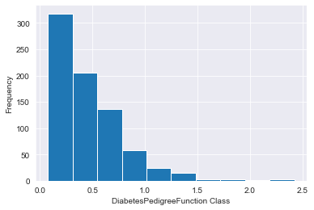

```python
#frequency count of DiabetesPedigreeFunction variable
plt.figure(figsize=(6,4))
plt.xlabel('DiabetesPedigreeFunction Class')
healthcare_df['DiabetesPedigreeFunction'].plot.hist()
sns.set_style(style='darkgrid')
```

Frequency count for each variable is plotted using histogam, except for pregnancies(barplot) and observed the summary of each variables.

**Checking for Imbalance in Data:**

```python
healthcare_df['Outcome'].value_counts().head()
```

```
0    500
1    268
Name: Outcome, dtype: int64
```

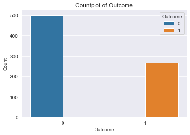

```python
sns.countplot(healthcare_df['Outcome'],hue=healthcare_df['Outcome'])
plt.title("Countplot of Outcome")
plt.xlabel('Outcome')
plt.ylabel("Count")
```

From the graph, it is clear that the data is imbalanced. Outcome Variable is biased towards zero value. This may affect the model and leads to Type 2 Error. Since the domain is healthcare, True Negatives are really dangerous compared to False positive. So planned to use SMOTE method to oversampling of data when building the model.

**Understanding Relationship between variables**

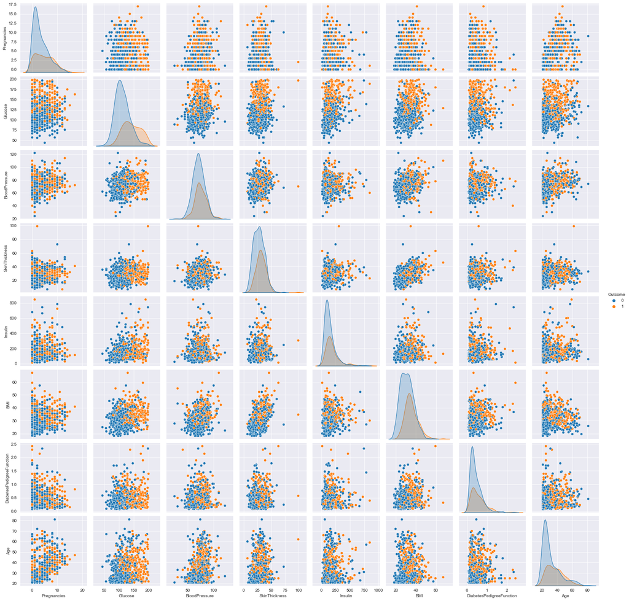

```python
sns.pairplot(healthcare_df, hue="Outcome")
```

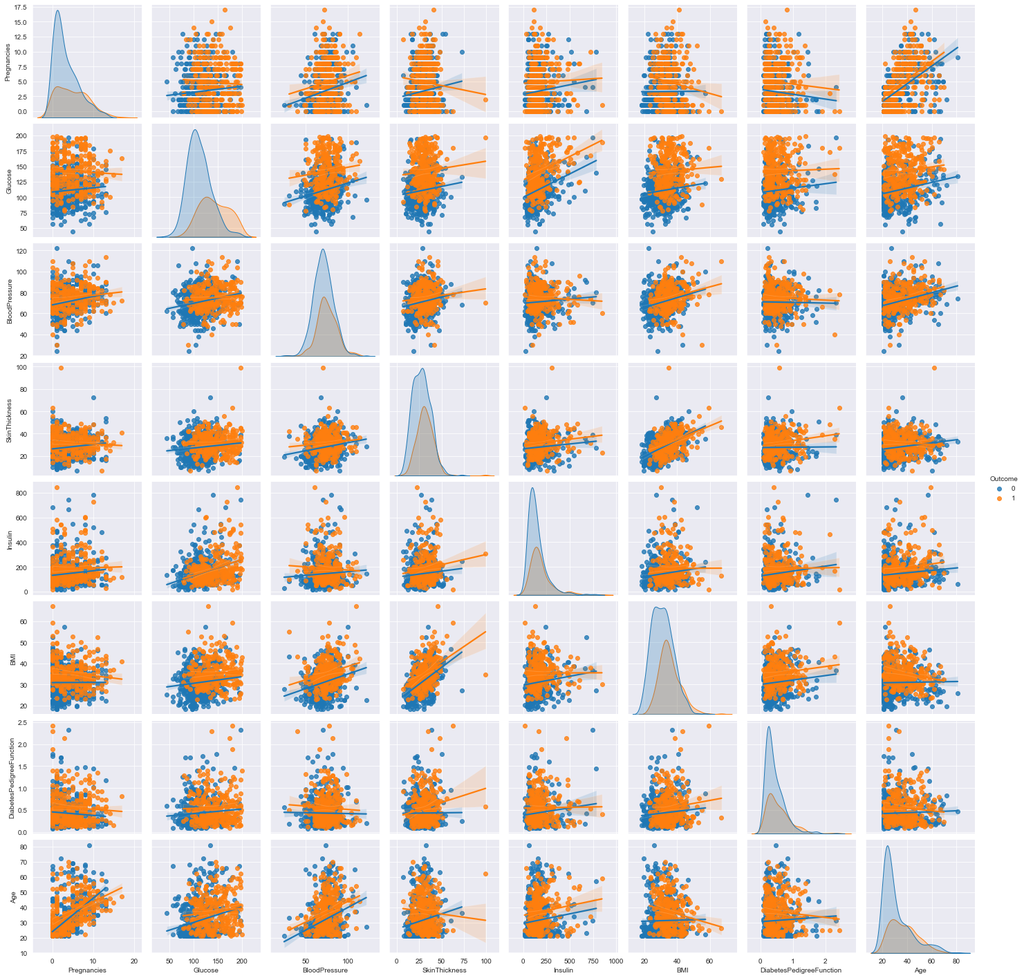

```python
sns.pairplot(healthcare_df, hue="Outcome", kind='reg')
```

From the above plots, it is observed that There is no strong multicolinearity among features.

- Skin thickness and BMI looks like it have a chance for positive correlation.
- As Known, Pregnancies and age has positive correlation.
- Insulin and Glucose may have slightly positive correlation.
- Outcome is positive in most of the cases when Glucose and BMI is higher.

```python
healthcare_df.corr()
```

|  | Pregnancies | Glucose | BloodPressure | SkinThickness | Insulin | BMI | DiabetesPedigreeFunction | Age | Outcome |
| --- | --- | --- | --- | --- | --- | --- | --- | --- | --- |
| Pregnancies | 1.000000 | 0.127964 | 0.208984 | 0.085915 | 0.113370 | 0.021546 | -0.033523 | 0.544341 | 0.221898 |
| Glucose | 0.127964 | 1.000000 | 0.219666 | 0.183711 | 0.359856 | 0.231478 | 0.137106 | 0.266600 | 0.492908 |
| BloodPressure | 0.208984 | 0.219666 | 1.000000 | 0.177192 | 0.052012 | 0.281231 | 0.000371 | 0.326740 | 0.162986 |
| SkinThickness | 0.085915 | 0.183711 | 0.177192 | 1.000000 | 0.138724 | 0.492320 | 0.103014 | 0.130788 | 0.196437 |
| Insulin | 0.113370 | 0.359856 | 0.052012 | 0.138724 | 1.000000 | 0.134465 | 0.099506 | 0.160328 | 0.186087 |
| BMI | 0.021546 | 0.231478 | 0.281231 | 0.492320 | 0.134465 | 1.000000 | 0.153508 | 0.025748 | 0.312254 |
| DiabetesPedigreeFunction | -0.033523 | 0.137106 | 0.000371 | 0.103014 | 0.099506 | 0.153508 | 1.000000 | 0.033561 | 0.173844 |
| Age | 0.544341 | 0.266600 | 0.326740 | 0.130788 | 0.160328 | 0.025748 | 0.033561 | 1.000000 | 0.238356 |
| Outcome | 0.221898 | 0.492908 | 0.162986 | 0.196437 | 0.186087 | 0.312254 | 0.173844 | 0.238356 | 1.000000 |

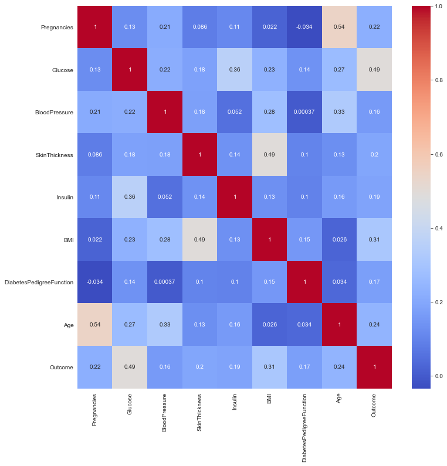

```python
plt.subplots(figsize=(12,12))
sns.heatmap(healthcare_df.corr(),annot=True,cmap='coolwarm')
```

The above heatmap proves the assumptions from the analysis of the pair plot are true.

**Data Modelling:**

```python
healthcare_df.columns
```

```
Index(['Pregnancies', 'Glucose', 'BloodPressure', 'SkinThickness', 'Insulin',
       'BMI', 'DiabetesPedigreeFunction', 'Age', 'Outcome'],
      dtype='object')
```

```python
X=healthcare_df.iloc[:,:-1].values
y=healthcare_df.iloc[:,-1].values
```

```python
print(X.shape)
print(y.shape)
```

```
(768, 8)
(768,)
```

```python
#spilling the dataset into train and test in the ratio 3:1
from sklearn.model_selection import train_test_split
X_train,X_test,y_train,y_test=train_test_split(X,y,test_size=0.25,random_state=5)
```

```python
print(X_train.shape)
print(y_train.shape)
print(X_test.shape)
print(y_test.shape)
```

```
(576, 8)
(576,)
(192, 8)
(192,)
```

**Standardization of dataset**

```python
#standardize the data using StandardScalar
from sklearn.preprocessing import StandardScaler
```

```python
Scaling=StandardScaler()
```

```python
X_train_scale=Scaling.fit_transform(X_train)
X_test_scale=Scaling.transform(X_test)
```

**Oversampling of Data(SMOTE):**

```python
 print("Before OverSampling, counts of label '1': {}".format(sum(y_train == 1)))
print("Before OverSampling, counts of label '0': {} \n".format(sum(y_train == 0)))
```

```
Before OverSampling, counts of label '1': 208
Before OverSampling, counts of label '0': 368
```

```python
#pip install imblearn
```

```python
#pip install delayed
```

```python
#importing SMOTE module from imblearn library
from imblearn.over_sampling import SMOTE
sm = SMOTE(random_state = 2)
X_train_res, y_train_res = sm.fit_resample(X_train_scale, y_train.ravel())
```

```python
#After Oversampling, checking for balance of data
print('After OverSampling, the shape of train_X: {}'.format(X_train_res.shape))
print('After OverSampling, the shape of train_y: {} \n'.format(y_train_res.shape))

print("After OverSampling, counts of label '1': {}".format(sum(y_train_res == 1)))
print("After OverSampling, counts of label '0': {}".format(sum(y_train_res == 0)))
```

```
After OverSampling, the shape of train_X: (736, 8)
After OverSampling, the shape of train_y: (736,)

After OverSampling, counts of label '1': 368
After OverSampling, counts of label '0': 368
```

**Thoughts on building Models:**

- From the above analysis it is observed that data is mostly numerical and variables are depending on target somewhat linearly. Hence Logistic Regression, Support Vector Vlassifier and Random Forest are expected to work fine.
- Also Building the models with other classification techniques such as Naive Bayes, Decision Tree Classifier and Compare all the models with KNN.
- Will build models without oversampling data to show the difference why oversampling is important for this model and how it reduces the Type 2 Error.
- To validate the models, train test split is used to test the trained model with test dataset.
- Will Interpret the accuracy using confusion matrix, classification matrix, ROC Curve and AUC Score.
- The model which gives high accuracy and high AUC score(less True Negatives) considered to be the good model.

**Logistic Regression**

```python
#Logistic Regression without Oversampling dataset
from sklearn.linear_model import LogisticRegression
model_lr = LogisticRegression()
model_lr.fit(X_train_scale,y_train)
```

```
LogisticRegression()
```

```python
pred_lr=model_lr.predict(X_test_scale)
```

```python
from sklearn import metrics
print("Logistic Regression Model Accuracy: ",metrics.accuracy_score(y_test,pred_lr))
```

```
Logistic Regression Model Accuracy:  0.7760416666666666
```

```python
from sklearn.metrics import classification_report
print(classification_report(y_test,pred_lr))
```

```
              precision    recall  f1-score   support

           0       0.84      0.83      0.84       132
           1       0.64      0.65      0.64        60

    accuracy                           0.78       192
   macro avg       0.74      0.74      0.74       192
weighted avg       0.78      0.78      0.78       192
```

```python
from sklearn.metrics import roc_curve
from sklearn.metrics import roc_auc_score
```

```python
prob_lr=model_lr.predict_proba(X_test_scale)
lr_roc=prob_lr[:,1]
fpr,tpr,thresholds=metrics.roc_curve(y_test,lr_roc)
roc_auc_lr=metrics.auc(fpr,tpr)
```

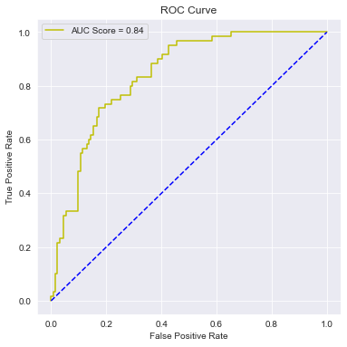

```python
plt.subplots(figsize=(6,6))
plt.title("ROC Curve")
plt.xlabel('False Positive Rate')
plt.ylabel('True Positive Rate')
plt.plot(fpr,tpr,'y',label='AUC Score = %0.2f'%roc_auc_lr)
plt.plot(fpr,fpr,'b--')
plt.legend()
```

**Logistic Regression(Oversampling data)**

```python
#logistic regression with oversampling data
model_lr_res = LogisticRegression(solver='liblinear', max_iter=100)
model_lr_res.fit(X_train_res,y_train_res)
pred_lr_res=model_lr_res.predict(X_test_scale)
```

```python
print("Logistic Regression Model with Resampling Accuracy: ",metrics.accuracy_score(y_test,pred_lr_res))
print(classification_report(y_test,pred_lr_res))
```

```
Logistic Regression Model with Resampling Accuracy:  0.7447916666666666
              precision    recall  f1-score   support

           0       0.88      0.73      0.80       132
           1       0.57      0.78      0.66        60

    accuracy                           0.74       192
   macro avg       0.72      0.76      0.73       192
weighted avg       0.78      0.74      0.75       192
```

```python
prob_lr_res=model_lr_res.predict_proba(X_test_scale)
lr_roc_res=prob_lr_res[:,1]
fpr,tpr,thresholds=metrics.roc_curve(y_test,lr_roc_res)
roc_auc_lr_res=metrics.auc(fpr,tpr)
```

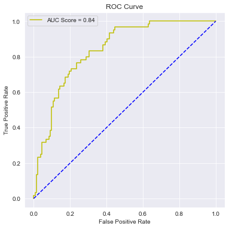

```python
plt.subplots(figsize=(6,6))
plt.title("ROC Curve")
plt.xlabel('False Positive Rate')
plt.ylabel('True Positive Rate')
plt.plot(fpr,tpr,'y',label='AUC Score = %0.2f'%roc_auc_lr_res)
plt.plot(fpr,fpr,'b--')
plt.legend()
```

Accuracy of Logistic Regression Model is higher than the Logistic Regression Model with Oversampling Data and AUC Score is equal. But Recall factor is better for Model with Oversampling Data and also True Negatives are lesser compared to the Model with normal data. Hence, Model with Oversampling Data Reduces Type 2 Error.

Let us check for Random Forest Classfier with and without Oversampling Data

**Random Forest Classifier**

```python
from sklearn.ensemble import RandomForestClassifier
model_rf = RandomForestClassifier(n_estimators=1000,random_state=21)
model_rf.fit(X_train_scale,y_train)
pred_rf=model_rf.predict(X_test_scale)
```

```python
print("Random Forest Model Accuracy: ",metrics.accuracy_score(y_test,pred_rf))
print(classification_report(y_test,pred_rf))
```

```
Random Forest Model Accuracy:  0.7916666666666666
              precision    recall  f1-score   support

           0       0.87      0.83      0.84       132
           1       0.65      0.72      0.68        60

    accuracy                           0.79       192
   macro avg       0.76      0.77      0.76       192
weighted avg       0.80      0.79      0.79       192
```

```python
prob_rf=model_rf.predict_proba(X_test_scale)
rf_roc=prob_rf[:,1]
fpr,tpr,thresholds=metrics.roc_curve(y_test,rf_roc)
roc_auc_rf=metrics.auc(fpr,tpr)
```

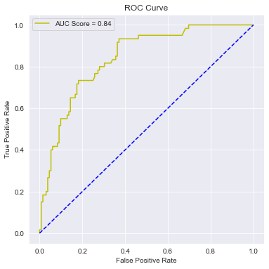

```python
plt.subplots(figsize=(6,6))
plt.title("ROC Curve")
plt.xlabel('False Positive Rate')
plt.ylabel('True Positive Rate')
plt.plot(fpr,tpr,'y',label='AUC Score = %0.2f'%roc_auc_rf)
plt.plot(fpr,fpr,'b--')
plt.legend()
```

**Random Forest Classifier(Oversampling data)**

```python
model_rf_res = RandomForestClassifier(n_estimators=1000,random_state=1)
model_rf_res.fit(X_train_res,y_train_res)
pred_rf_res=model_rf_res.predict(X_test_scale)
```

```python
print("Random Forest Model with Resampling Accuracy: ",metrics.accuracy_score(y_test,pred_rf_res))
print(classification_report(y_test,pred_rf_res))
```

```
Random Forest Model with Resampling Accuracy:  0.7708333333333334
              precision    recall  f1-score   support

           0       0.89      0.77      0.82       132
           1       0.60      0.78      0.68        60

    accuracy                           0.77       192
   macro avg       0.74      0.77      0.75       192
weighted avg       0.80      0.77      0.78       192
```

```python
prob_rf_res=model_rf_res.predict_proba(X_test_scale)
rf_roc_res=prob_rf_res[:,1]
fpr,tpr,thresholds=metrics.roc_curve(y_test,rf_roc_res)
roc_auc_rf_res=metrics.auc(fpr,tpr)
```

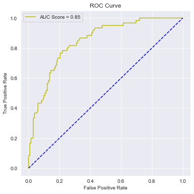

```python
plt.subplots(figsize=(6,6))
plt.title("ROC Curve")
plt.xlabel('False Positive Rate')
plt.ylabel('True Positive Rate')
plt.plot(fpr,tpr,'y',label='AUC Score = %0.2f'%roc_auc_rf_res)
plt.plot(fpr,fpr,'b--')
plt.legend()
```

Accuracy of Random Forest Model is higher than the Random Forest Model with Oversampling Data. But AUC Score is higher for RF model with Oversampling Data and also Recall factor is better for Model with Oversampling Data and also True Negatives are lesser compared to the Model with normal data. Hence, Model with Oversampling Data Reduces Type 2 Error.

For Logistic Regression and Random Forest Model that build with Oversampling Data works well and Reduces Type 2 Error. Hence we proceed with the other classifier models with oversampling Data only.

**Support Vector Classifier**

```python
from sklearn.svm import SVC
model_svc = SVC(random_state=21,probability=True)
model_svc.fit(X_train_res,y_train_res)
pred_svc=model_svc.predict(X_test_scale)
```

```python
from sklearn.svm import SVC
model_svc_linear = SVC(kernel='linear',random_state=21,probability=True)
model_svc_linear.fit(X_train_res,y_train_res)
pred_svc_linear=model_svc_linear.predict(X_test_scale)
```

```python
print("SVM rbf Model Accuracy: ",metrics.accuracy_score(y_test,pred_svc))
print(classification_report(y_test,pred_svc))
```

```
SVM rbf Model Accuracy:  0.75
              precision    recall  f1-score   support

           0       0.90      0.72      0.80       132
           1       0.57      0.82      0.67        60

    accuracy                           0.75       192
   macro avg       0.73      0.77      0.73       192
weighted avg       0.79      0.75      0.76       192
```

```python
print("SVM Linear Model Accuracy: ",metrics.accuracy_score(y_test,pred_svc_linear))
print(classification_report(y_test,pred_svc_linear))
```

```
SVM Linear Model Accuracy:  0.7291666666666666
              precision    recall  f1-score   support

           0       0.88      0.70      0.78       132
           1       0.55      0.78      0.64        60

    accuracy                           0.73       192
   macro avg       0.71      0.74      0.71       192
weighted avg       0.77      0.73      0.74       192
```

```python
prob_svc=model_svc.predict_proba(X_test_scale)
svc_roc=prob_svc[:,1]
fpr,tpr,thresholds=metrics.roc_curve(y_test,svc_roc)
roc_auc_svc=metrics.auc(fpr,tpr)
```

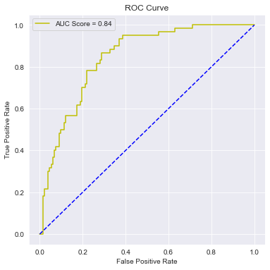

```python
plt.subplots(figsize=(6,6))
plt.title("ROC Curve")
plt.xlabel('False Positive Rate')
plt.ylabel('True Positive Rate')
plt.plot(fpr,tpr,'y',label='AUC Score = %0.2f'%roc_auc_svc)
plt.plot(fpr,fpr,'b--')
plt.legend()
```

Support Vector Classifier with kernel 'rbf' model works better compared to Support Vector Classifier kernel 'linear' model

**Desicion Tree Classifier**

```python
from sklearn.tree import DecisionTreeClassifier
model_dt = DecisionTreeClassifier()
model_dt.fit(X_train_res,y_train_res)
pred_dt=model_dt.predict(X_test_scale)
```

```python
print("Decision Tree Model Accuracy: ",metrics.accuracy_score(y_test,pred_dt))
print(classification_report(y_test,pred_dt))
```

```
Decision Tree Model Accuracy:  0.6822916666666666
              precision    recall  f1-score   support

           0       0.81      0.70      0.75       132
           1       0.49      0.65      0.56        60

    accuracy                           0.68       192
   macro avg       0.65      0.67      0.66       192
weighted avg       0.71      0.68      0.69       192
```

```python
prob_dt=model_dt.predict_proba(X_test_scale)
dt_roc=prob_dt[:,1]
fpr,tpr,thresholds=metrics.roc_curve(y_test,dt_roc)
roc_auc_dt=metrics.auc(fpr,tpr)
```

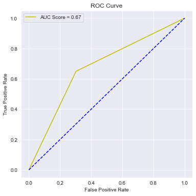

```python
plt.subplots(figsize=(6,6))
plt.title("ROC Curve")
plt.xlabel('False Positive Rate')
plt.ylabel('True Positive Rate')
plt.plot(fpr,tpr,'y',label='AUC Score = %0.2f'%roc_auc_dt)
plt.plot(fpr,fpr,'b--')
plt.legend()
```

**K-Nearest Neighbour**

```python
from sklearn.neighbors import KNeighborsClassifier
model_knn = KNeighborsClassifier(n_neighbors=8)
model_knn.fit(X_train_res,y_train_res)
pred_knn=model_knn.predict(X_test_scale)
```

```python
print("KNN Model Accuracy: ",metrics.accuracy_score(y_test,pred_knn))
print(classification_report(y_test,pred_knn))
```

```
KNN Model Accuracy:  0.7395833333333334
              precision    recall  f1-score   support

           0       0.88      0.72      0.79       132
           1       0.56      0.78      0.65        60

    accuracy                           0.74       192
   macro avg       0.72      0.75      0.72       192
weighted avg       0.78      0.74      0.75       192
```

```python
prob_knn=model_knn.predict_proba(X_test_scale)
knn_roc=prob_knn[:,1]
fpr,tpr,thresholds=metrics.roc_curve(y_test,knn_roc)
roc_auc_knn=metrics.auc(fpr,tpr)
```

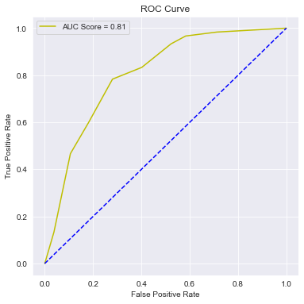

```python
plt.subplots(figsize=(6,6))
plt.title("ROC Curve")
plt.xlabel('False Positive Rate')
plt.ylabel('True Positive Rate')
plt.plot(fpr,tpr,'y',label='AUC Score = %0.2f'%roc_auc_knn)
plt.plot(fpr,fpr,'b--')
plt.legend()
```

KNN Model shows good accuracy but there are models works better than KNN model. Logistic Regression Model(res),Random Forest Model(res), SVC rbf model shows better results than KNN Model. However Naive Bayes(gaussianNB and bernoulliNB), Decision Tree Model shows poorer results than KNN Model. note: res denotes Model with Oversampling Data(Resampling)

**Naive Bayes GaussianNB**

```python
from sklearn.naive_bayes import GaussianNB
model_nb = GaussianNB()
model_nb.fit(X_train_res,y_train_res)
pred_nb=model_nb.predict(X_test_scale)
```

```python
print("Naive Bayes Gaussian Model Accuracy: ",metrics.accuracy_score(y_test,pred_nb))
print(classification_report(y_test,pred_nb))
```

```
Naive Bayes Gaussian Model Accuracy:  0.7291666666666666
              precision    recall  f1-score   support

           0       0.86      0.72      0.79       132
           1       0.55      0.75      0.63        60

    accuracy                           0.73       192
   macro avg       0.71      0.73      0.71       192
weighted avg       0.77      0.73      0.74       192
```

```python
prob_nb=model_nb.predict_proba(X_test_scale)
nb_roc=prob_nb[:,1]
fpr,tpr,thresholds=metrics.roc_curve(y_test,nb_roc)
roc_auc_nb=metrics.auc(fpr,tpr)
```

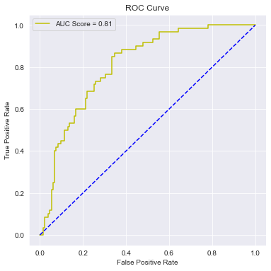

```python
plt.subplots(figsize=(6,6))
plt.title("ROC Curve")
plt.xlabel('False Positive Rate')
plt.ylabel('True Positive Rate')
plt.plot(fpr,tpr,'y',label='AUC Score = %0.2f'%roc_auc_nb)
plt.plot(fpr,fpr,'b--')
plt.legend()
```

**Naive Bayes BernoulliNB**

```python
from sklearn.naive_bayes import BernoulliNB
model_nbb = BernoulliNB()
model_nbb.fit(X_train_res,y_train_res)
pred_nbb=model_nbb.predict(X_test_scale)
```

```python
print("Naive Bayes Bernoulli Model Accuracy: ",metrics.accuracy_score(y_test,pred_nbb))
print(classification_report(y_test,pred_nbb))
```

```
Naive Bayes Bernoulli Model Accuracy:  0.65625
              precision    recall  f1-score   support

           0       0.82      0.64      0.72       132
           1       0.47      0.68      0.55        60

    accuracy                           0.66       192
   macro avg       0.64      0.66      0.64       192
weighted avg       0.71      0.66      0.67       192
```

```python
prob_nbb=model_nbb.predict_proba(X_test_scale)
nbb_roc=prob_nbb[:,1]
fpr,tpr,thresholds=metrics.roc_curve(y_test,nbb_roc)
roc_auc_nbb=metrics.auc(fpr,tpr)
```

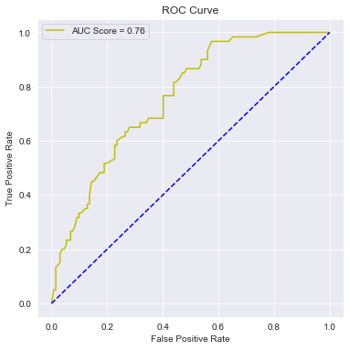

```python
plt.subplots(figsize=(6,6))
plt.title("ROC Curve")
plt.xlabel('False Positive Rate')
plt.ylabel('True Positive Rate')
plt.plot(fpr,tpr,'y',label='AUC Score = %0.2f'%roc_auc_nbb)
plt.plot(fpr,fpr,'b--')
plt.legend()
```

GaussianNB Model works better than BernoulliNB model

```python
#Confusion Matrix for all models
from sklearn.metrics import confusion_matrix
print("Linear Regression: ",confusion_matrix(y_test,pred_lr))
print("Linear Regression with Resampling: ",confusion_matrix(y_test,pred_lr_res))
print("Random Forest: ",confusion_matrix(y_test,pred_rf))
print("Random Forest with Resampling: ",confusion_matrix(y_test,pred_rf_res))
print("Support Vector Classifier rbf: ",confusion_matrix(y_test,pred_svc))
print("Decision Tree: ",confusion_matrix(y_test,pred_dt))
print("K-Nearest Neighbour: ",confusion_matrix(y_test,pred_knn))
print("Naive Bayes Gaussian: ",confusion_matrix(y_test,pred_nb))
print("Naive Bayes Beroulli: ",confusion_matrix(y_test,pred_nbb))
```

```
Linear Regression:  [[110  22]
 [ 21  39]]
Linear Regression with Resampling:  [[96 36]
 [13 47]]
Random Forest:  [[109  23]
 [ 17  43]]
Random Forest with Resampling:  [[101  31]
 [ 13  47]]
Support Vector Classifier rbf:  [[95 37]
 [11 49]]
Decision Tree:  [[92 40]
 [21 39]]
K-Nearest Neighbour:  [[95 37]
 [13 47]]
Naive Bayes Gaussian:  [[95 37]
 [15 45]]
Naive Bayes Beroulli:  [[85 47]
 [19 41]]
```

As Overall, **Random Forest Model(res)** and **Support Vector Classifier rbf Model** are the best for this data.